# Assignment_2_WeatherStationMapping

## Setup

```python
import pyspark
from pyspark.sql import SparkSession
from pyspark.sql import functions as F,types as T
from pyspark.sql import Row
```

```python
from pprint import pprint
```

```python
#Creating Spark Session
spark = SparkSession.builder.appName("WeatherStations").getOrCreate()
```

## Load Data

```python
#Reading WeatherStation Data
stations = spark.read.csv("Datasets/2000_2013/WeatherStations.csv",header=True)
```

```python
#Check number of rows
stations.count()
```

```
2868
```

```python
#CheckSchema
stations.printSchema()
```

```
root
 |-- SN: string (nullable = true)
 |-- STATE NAME: string (nullable = true)
 |-- DISTRICT NAME: string (nullable = true)
 |-- STATION NAME: string (nullable = true)
 |-- CLASS: string (nullable = true)
 |-- LAT: string (nullable = true)
 |-- LON: string (nullable = true)
 |-- HEIGHT(MTR): string (nullable = true)
 |-- CATCH: string (nullable = true)
```

```python
#Check Data
stations.show()
```

```
+---+----------+-------------+----------------+-----+-----+-----+-----------+-----+
| SN|STATE NAME|DISTRICT NAME|    STATION NAME|CLASS|  LAT|  LON|HEIGHT(MTR)|CATCH|
+---+----------+-------------+----------------+-----+-----+-----+-----------+-----+
|  1|    ANDHRA|     ADILABAD|         MUDHOLE|  REV|18.58|77.55|       0339|  313|
|  2|    ANDHRA|     ADILABAD|  MANCHERIAL%RAL|  PWD|18.52|79.26|       0143|  313|
|  3|    ANDHRA|     ADILABAD|CHINNUR%CHINNOOR|  REV|18.51|79.48|       0135|  313|
|  4|    ANDHRA|     ADILABAD|      LUXETTIPET|  REV|18.53|79.13|       0163|  313|
|  5|    ANDHRA|     ADILABAD|          NIRMAL|  REV|19.06|78.21|       0323|  313|
|  6|    ANDHRA|     ADILABAD|          UTNOOR|  REV|19.22|78.46|           |  313|
|  7|    ANDHRA|     ADILABAD|           BOATH|  REV|19.20|78.19|       0435|  313|
|  8|    ANDHRA|     ADILABAD|        KHANAPUR|  REV|19.02|78.39|       0242|  313|
|  9|    ANDHRA|     ADILABAD|          KADDAM|  PWD|19.05|78.45|       0223|  313|
| 10|    ANDHRA|     ADILABAD|        ASIFABAD|  REV|19.22|79.18|       0210|  313|
| 11|    ANDHRA|     ADILABAD|        ADILABAD| OBSY|19.39|78.32|       0209|  314|
| 12|    ANDHRA|     ADILABAD|          SIRPUR|  REV|19.28|79.36|       0184|  314|
| 13|    ANDHRA|    ANANTAPUR|      MADAKASIRA|  REV|13.56|77.16|       0672|  304|
| 14|    ANDHRA|    ANANTAPUR|        HINDUPUR|  REV|13.49|77.29|       0618|  304|
| 15|    ANDHRA|    ANANTAPUR|     CHILAMATTUR|  REV|13.50|77.42|           |  304|
| 16|    ANDHRA|    ANANTAPUR|       PENUKONDA|     |14.05|77.35|       0618|  304|
| 17|    ANDHRA|    ANANTAPUR|          PAMIDI|  REV|14.56|77.35|           |  304|
| 18|    ANDHRA|    ANANTAPUR|     DHARMAVARAM|  REV|14.25|77.43|       0365|  304|
| 19|    ANDHRA|    ANANTAPUR|      KALYANDRUG|  REV|14.33|77.07|       0562|  304|
| 20|    ANDHRA|    ANANTAPUR|        ANANTPUR| OBSY|14.41|77.39|           |  304|
+---+----------+-------------+----------------+-----+-----+-----+-----------+-----+
only showing top 20 rows
```

## Data Validation

```python
#Listing out Distinct States
stations.select("STATE NAME").distinct().show(n=40)
```

```
+----------+
|STATE NAME|
+----------+
|    SIKKIM|
| MEGHALAYA|
|   UNION.T|
|      U.P.|
|   J AND K|
|       GOA|
| RAJASTHAN|
|   TRIPURA|
| W. BENGAL|
|     DELHI|
| ARUNACHAL|
|   GUJARAT|
|     BIHAR|
| KARNATAKA|
|UTARANCHAL|
|    ORISSA|
|   MANIPUR|
|    ANDHRA|
|    PUNJAB|
|  EX-INDIA|
|  NAGALAND|
|  HIMACHAL|
|   HARYANA|
|   MIZORAM|
|      M.P.|
| TAMILNADU|
|       MAH|
|    KERALA|
|     ASSAM|
|  RAJASTAN|
| JHARKHAND|
|CHATISGARH|
+----------+
```

The names for states are not in Standard form.

Union Territories are grouped as *Union.T*.

There is also the value *EX-INDIA* that needs to be checked.

Also the data does not represent the state of Telangana.

```python
stations.filter(stations["STATE NAME"]=="UNION.T").show()
```

```
+----+----------+---------------+------------+-----+-----+-----+-----------+-----+
|  SN|STATE NAME|  DISTRICT NAME|STATION NAME|CLASS|  LAT|  LON|HEIGHT(MTR)|CATCH|
+----+----------+---------------+------------+-----+-----+-----+-----------+-----+
|2337|   UNION.T|DADRA N. HAVELI|      NAROLI|     |20.18|72.58|       0152|  102|
|2338|   UNION.T|DADRA N. HAVELI|    SILVASSA|     |20.18|73.03|       0152|  102|
|2339|   UNION.T|DADRA N. HAVELI|     KHANVEL|     |20.08|73.03|       0152|  102|
|2340|   UNION.T|DADRA N. HAVELI|     DUDHANI|     |20.13|73.08|       0152|  102|
|2341|   UNION.T|DADRA N. HAVELI|    KILAVANI|     |20.18|73.03|       0152|  102|
|2342|   UNION.T|DADRA N. HAVELI|     MADHBUN|     |   . |   . |           |     |
|2343|   UNION.T|          DAMAN|       DAMAN|     |20.25|72.51|       0012|  102|
|2344|   UNION.T|            DIU|         DIU| OBSY|20.43|70.55|       0015|  107|
|2345|   UNION.T|     PUDUCHERRY|    KARAIKAL| OBSY|10.55|79.50|       0007|  301|
|2346|   UNION.T|     PUDUCHERRY|  PUDUCHERRY| OBSY|11.55|79.50|       0006|  303|
|2347|   UNION.T|     CHANDIGARH|  CHANDIGARH| OBSY|30.44|76.53|       0347|  202|
+----+----------+---------------+------------+-----+-----+-----+-----------+-----+
```

```python
stations.filter(stations["STATE NAME"]=="EX-INDIA").show()
```

```
+----+----------+-------------+------------+-----+-----+-----+-----------+-----+
|  SN|STATE NAME|DISTRICT NAME|STATION NAME|CLASS|  LAT|  LON|HEIGHT(MTR)|CATCH|
+----+----------+-------------+------------+-----+-----+-----+-----------+-----+
|2687|  EX-INDIA|  LAKSHADWEEP|     MINICOY| OBSY|08.18|73.09|       0001|     |
|2688|  EX-INDIA|  LAKSHADWEEP|      AGATHI| OBSY|10.51|72.28|       0003|     |
|2689|  EX-INDIA|  LAKSHADWEEP|   KAVARATTI| OBSY|10.32|72.37|       0003|     |
|2690|  EX-INDIA|  LAKSHADWEEP|       AMINI| OBSY|11.07|72.44|       0003|     |
|2691|  EX-INDIA|  BAY ISLANDS|      KONDUL| OBSY|07.13|93.44|       0008|     |
|2692|  EX-INDIA|  BAY ISLANDS|   NANCOWARY| OBSY|07.59|93.32|       0026|     |
|2693|  EX-INDIA|  BAY ISLANDS| CAR NICOBAR| OBSY|09.10|92.50|       0010|     |
|2694|  EX-INDIA|  BAY ISLANDS|     HUT BAY| OBSY|10.35|92.33|       0005|     |
|2695|  EX-INDIA|  BAY ISLANDS|  PORT BLAIR| OBSY|11.40|92.43|       0079|     |
|2696|  EX-INDIA|  BAY ISLANDS| MAYA BANDAR| OBSY|12.55|92.55|       0028|     |
|2697|  EX-INDIA|  BAY ISLANDS| LONG ISLAND| OBSY|12.25|92.56|       0025|     |
+----+----------+-------------+------------+-----+-----+-----+-----------+-----+
```

This is the data for Lakshadweep and Andaman and Nicobar Islands.

```python
stations.filter(stations["STATE NAME"]=="J AND K").select("DISTRICT NAME").distinct().show()
```

```
+-------------+
|DISTRICT NAME|
+-------------+
|       BADGAM|
|      KUPWARA|
|       KARGIL|
|    BARAMULLA|
|     ANANTNAG|
|         DODA|
|     SRINAGAR|
|       KATHUA|
|        JAMMU|
|     UDHAMPUR|
|      PULWAMA|
|       LADAKH|
+-------------+
```

```python
stations.filter(F.col("STATE NAME")=="ANDHRA").select("DISTRICT NAME").distinct().show(n=40)
```

```
+-------------+
|DISTRICT NAME|
+-------------+
|      CHITTOR|
|       GUNTUR|
|    ANANTAPUR|
|     ADILABAD|
|VISAKHAPATNAM|
|EAST GODAVARI|
|    HYDERABAD|
|     WARANGAL|
|     NIZAMBAD|
|     NALGONDA|
|      NELLORE|
|     CUDDAPAH|
|   RANGAREDDY|
|   KARIMNAGAR|
|    NIZAMABAD|
|  MAHBUBNAGAR|
|     PRAKASAM|
|      KHAMMAM|
|WEST GODAVARI|
|        MEDAK|
|      KURNOOL|
|   SRIKAKULAM|
|      KRISHNA|
| VIZIANAGARAM|
+-------------+
```

## Correcting State Names

```python
#Lets map States to their proper name
stateNames= {
    "U.P.":"UTTAR PRADESH",
    "J AND K":"JAMMU AND KASHMIR",
    "W. BENGAL":"WEST BENGAL",
    "DELHI":"NEW DELHI",
    "ARUNACHAL":"ARUNACHAL PRADESH",
    "UTARANCHAL":"UTTARAKHAND",
    "HIMACHAL":"HIMACHAL PRADESH",
    "M.P.":"MADHAYA PRADESH",
    "MAH":"MAHARASHTRA",
    "RAJASTAN":"RAJASTHAN"
}

unionTerritories = {
    "DADRA N. HAVELI" : "DADRA AND NAGAR HAVELI",
    "DAMAN":"DAMAN AND DIU",
    "DIU":"DAMAN AND DIU",
    "PUDUCHERRY":"PUDUCHERRY",
    "CHANDIGARH":"CHANDIGARH",
    "LAKSHADWEEP":"LAKSHADWEEP",
    "BAY ISLANDS":"ANDAMAN AND NICOBAR ISLANDS"
}

andhraDistricts = ["CHITTOR","GUNTUR","ANANTAPUR",
                   "VISAKHAPATNAM","EAST GODAVARI","NELLORE",
                   "CUDDAPAH","PRAKASAM","WEST GODAVARI",
                   "KURNOOL","SRIKAKULAM","KRISHNA","VIZIANAGARAM"]

def mapStateNames(state,district):
    if state=="EX-INDIA" or state=="UNION.T":
        return unionTerritories[district]
    elif district == "LADAKH" or district == "KARGIL":
        return "LADAKH"
    elif state == "ANDHRA":
        return "ANDHRA PRADESH" if district in andhraDistricts else "TELANGANA"
    elif state in stateNames.keys():
        return stateNames[state]
    return state
```

```python
#Create Spark UDF
mapStateNames = F.udf(mapStateNames,T.StringType())
```

```python
#Applying Spark UDF to correct Names
stations = stations.withColumn("STATE NAME",mapStateNames("STATE NAME","DISTRICT NAME"))
```

```python
#Listing out Distinct States
stations.select("STATE NAME").distinct().show(n=40)
```

```
+--------------------+
|          STATE NAME|
+--------------------+
|              SIKKIM|
|           MEGHALAYA|
|         WEST BENGAL|
|           NEW DELHI|
|                 GOA|
|           RAJASTHAN|
|             TRIPURA|
|       DAMAN AND DIU|
|    HIMACHAL PRADESH|
|             GUJARAT|
|               BIHAR|
|          CHANDIGARH|
|           KARNATAKA|
|              ORISSA|
|     MADHAYA PRADESH|
|       UTTAR PRADESH|
|ANDAMAN AND NICOB...|
|             MANIPUR|
|         LAKSHADWEEP|
|          PUDUCHERRY|
|         MAHARASHTRA|
|              PUNJAB|
|            NAGALAND|
|DADRA AND NAGAR H...|
|   ARUNACHAL PRADESH|
|         UTTARAKHAND|
|             HARYANA|
|             MIZORAM|
|   JAMMU AND KASHMIR|
|           TELANGANA|
|           TAMILNADU|
|              LADAKH|
|      ANDHRA PRADESH|
|              KERALA|
|               ASSAM|
|           JHARKHAND|
|          CHATISGARH|
+--------------------+
```

## Check for errors in District Names

```python
def generateDistrictList(dataframe,state):
    districtlist= (dataframe
                 .filter(F.col("STATE NAME")==state)
                 .select("DISTRICT NAME")
                 .distinct().collect())
    return [row["DISTRICT NAME"] for row in districtlist]

def generateStateMap(dataframe,states):
    districts = {state:generateDistrictList(dataframe,state) for state in states}
    return districts
```

```python
states = [row["STATE NAME"]   for row in stations.select("STATE NAME").distinct().collect()]
```

```python
districts = generateStateMap(stations,states)
```

```python
pprint(districts)
```

```
{'ANDAMAN AND NICOBAR ISLANDS': ['BAY ISLANDS'],
 'ANDHRA PRADESH': ['CHITTOR',
                    'GUNTUR',
                    'ANANTAPUR',
                    'VISAKHAPATNAM',
                    'EAST GODAVARI',
                    'NELLORE',
                    'CUDDAPAH',
                    'PRAKASAM',
                    'WEST GODAVARI',
                    'KURNOOL',
                    'SRIKAKULAM',
                    'KRISHNA',
                    'VIZIANAGARAM'],
 'ARUNACHAL PRADESH': ['EAST KAMENG',
                       'LOWER SUBANSIRI',
                       'DIBANG VALLEY',
                       'TAWANG',
                       'WEST KAMENG',
                       'CHANGLANG',
                       'WEST SIANG',
                       'LOHIT',
                       'UPPER SIANG',
                       'TIRAP',
                       'EAST SIANG',
                       'PAPAMPARE',
                       'UPPER SUBANSIRI'],
 'ASSAM': ['NOWGONG',
           'JORHAT',
           'SIBSAGAR',
           'GOALPARA',
           'DIBRUGARH',
           'BONGAIGAON',
           'HAILAKANDI',
           'KOKRAJHAR',
           'TINSUKIA',
           'KARBI ANGLONG',
           'N.C.HILLS',
           'KARIMGANJ',
           'CACHAR',
```

[output cut: 474 more lines]

```
                 'JALPAIGURI',
                 'HOWRAH',
                 '24 PARNANAS N',
                 'MANBHUM%PURULI',
                 'BANKURA',
                 'COOCH BEHAR',
                 'HOOGLY',
                 '24 PARGANAS S',
                 'DINAJPUR SOUTH',
                 'MALDA',
                 'DINAJPUR NORTH',
                 'MURSHIDABAD',
                 'BIRBHUM',
                 'BURDWAN',
                 '24 PARGANAS N']}
```

### Inconsistencies Noted:

With respect to Data Available from: https://knowindia.gov.in/districts/

1. Assam:
   - NAGAON as NOWGONG
   - SIVASAGAR as SIBSAGAR
   - DIMA HASAO(North Cachar Hills) as N.C.HILLS
1. BIHAR
   - KAIMUR as BHABUA
   - **GODDA (Now part of Jharkhand)**
   - JEHANABAD as JAHANABAD
   - NAWADA as NAWADAH
1. CHHATTISGARH
   - KAWARDHA as KOWARDHA
   - KOREA as KORIYA
   - JASHPUR as JASHPURNAGAR
   - JANJGIR CHAMPA as JANJGIR
1. DADRA AND NAGAR HAVELI
   - DADRA AND NAGAR HAVELI as DADRA N. HAVELI
1. GUJRAT
   - VADODARA as BARODA
   - **BHAVNAGAR is present as BHAVNAGAR and BHAUNAGAR**
   - VALSAD as BULSAR/VALSAD
   - KHEDA as KAIRA/KHEDA
   - DAHOD as DOHAD
1. HIMACHAL PRADESH
   - SHIMLA as SIMLA/MAHASU
   - SIRMAUR as SIRMUR
1. KARNATAKA
   - BELGAVI as BELGAUM
   - VIJAYPURA as BIJAPUR
   - CHAMARAJANAGAR as CHAMARAJANAGA
   - KALABURAGI as GULBARGA
   - KANNAD SOUTH as KANARA SOUTH
   - KANNAD NORTH as KANARA NORTH
   - SHIVAMOGGA as SHIMOGA
   - TUMAKURU as TUMKUR
1. KERELA
   - THIRUVANANTHAPURAM as THIRUVANANTHAP
1. MADHYA PRADESH
   - **HOSHANGABAD is present as HOSHANGABAD and HOSHANGBAD**
1. MAHARASHTRA
   - AMRAVATI as AMRAOTI
   - BEED as BHIR
   - DHULE as DHULIA
   - RAIGAD as KOLABA/RAIGARH
   - PUNE as POONA
   - YAVATMAL as YEOTMAL
   - THANE as THANA
   - **MUMBAI CITY as BOMBAY %CITY<**
1. MIZORAM
   - AIZAWL as AIZAWAL
   - SAIHA as CHHIMTUIPUI
1. ODISHA
   - NUAPADA as NAWAPARA
   - NABHRANGPUR as NAWARANGPUR
   - **SUNDARGARH is present as SUNDARGARH and SUNDERGARH**
1. PUNJAB
   - JALANDHAR as JULLUNDAR
   - FEROZPUR as FEROZEPORE
1. TAMILNADU
   - RAMANATHAPURAM as RAMANATHAPURA
1. TELANGANA
   - **NIZAMABAD is present as NIZAMABAD and NIZAMBAD**
1. UTTAR PRADESH
   - AMETHI as SHAHUJI M NAGAR
1. WEST BENGAL
   - **24 PARGANAS N is present as 24 PARGANAS N and 24 PARNANAS N**
   - **PURULIA is present as MANBHUM%PURULI**

Note: Only inconsistencies marked in bold are being resolved as they can generate errors

## Correct District Names

```python
districtNames={
    "GUJARAT"         : {"BHAUNAGAR":"BHAVNAGAR"},
    "MADHAYA PRADESH" :{"HOSHANGBAD":"HOSHANGABAD"},
    "MAHARASHTRA"    : {"BOMBAY %CITY<":"MUMBAI CITY"},
    "ORISSA"         : {"SUNDERGARH":"SUNDARGARH"},
    "TELANGANA"      : {"NIZAMBAD" : "NIZAMABAD"},
    "WEST BENGAL"    : {"24 PARNANAS N" : "24 PARGANAS N",
                        "MANBHUM%PURULI": "PURULIA"}
}
```

```python
def correctDistrictDetails(row):

    if row["STATE NAME"] in districtNames:
        if row["DISTRICT NAME"] in districtNames[row["STATE NAME"]]:
            row= row.asDict()
            row["DISTRICT NAME"] = districtNames[row["STATE NAME"]][row["DISTRICT NAME"]]
            return Row(**row)
    if row["STATE NAME"]=="BIHAR" and row["DISTRICT NAME"]=="GODDA":
        row= row.asDict()
        row["STATE NAME"] = "JHARKHAND"
        return Row(**row)
    return row
```

```python
stations = spark.createDataFrame(data = stations.rdd.map(lambda row: correctDistrictDetails(row)))
```

```python
#Checking that all changes have taken place
generateStateMap(stations,states)
```

```
{'SIKKIM': ['SOUTHSIKKIM', 'EAST SIKKIM'],
 'MEGHALAYA': ['JAINTIA HILLS',
  'EAST GARO HILLS',
  'EAST KHASI HILLS',
  'WEST GARO HILLS'],
 'WEST BENGAL': ['PURULIA',
  'MIDNAPORE',
  'NADIA',
  'DARJEELING',
  'JALPAIGURI',
  'HOWRAH',
  'BANKURA',
  'COOCH BEHAR',
  'HOOGLY',
  '24 PARGANAS S',
  'DINAJPUR SOUTH',
  'MALDA',
  'DINAJPUR NORTH',
  'MURSHIDABAD',
  'BIRBHUM',
  'BURDWAN',
  '24 PARGANAS N'],
 'NEW DELHI': ['DELHI'],
 'GOA': ['NORTH GOA', 'SOUTH GOA'],
 'RAJASTHAN': ['JAISALMER',
  'BIKANER',
  'CHURU',
  'TONK',
  'JHUNJHUNU',
  'RAJASMAND',
  'JHALAWAR',
  'SIROHI',
  'BHARATPUR',
  'AJMER',
  'HANUMANGARH',
  'JALORE',
  'BHILWARA',
  'JODHPUR',
  'DUNGARPUR',
  'BUNDI',
```

[output cut: 469 more lines]

```
  'SURGUJA',
  'RAIGARH',
  'DHAMTARI',
  'KORBA',
  'DURG',
  'KANKER',
  'JANJGIR',
  'BASTAR',
  'MAHASAMUND',
  'JASHPURNAGAR',
  'BILASPUR',
  'DANTEWARA',
  'KORIYA',
  'KOWARDHA',
  'RAIPUR']}
```

## Schema Correction and Projecting required Columns

```python
#We need to add Station ID from StationID file
#For this purpose Latitude and Longitude need to be Numerical Datatype

#Casting Latitude(LAT) and Longitude(LON) to DoubleType
stations = ( stations
             .withColumn("Latitude",F.col("LAT").cast(T.DoubleType()))
             .withColumn("Longitude",F.col("LON").cast(T.DoubleType()))
             .withColumnRenamed("STATE NAME","State")
             .withColumnRenamed("DISTRICT NAME","District")
           )
```

```python
#Projecting to required fields
stations = stations.select(["State","District","Latitude","Longitude"])
stations.printSchema()
```

```
root
 |-- State: string (nullable = true)
 |-- District: string (nullable = true)
 |-- Latitude: double (nullable = true)
 |-- Longitude: double (nullable = true)
```

```python
#checking data
stations.show()
```

```
+--------------+---------+--------+---------+
|         State| District|Latitude|Longitude|
+--------------+---------+--------+---------+
|     TELANGANA| ADILABAD|   18.58|    77.55|
|     TELANGANA| ADILABAD|   18.52|    79.26|
|     TELANGANA| ADILABAD|   18.51|    79.48|
|     TELANGANA| ADILABAD|   18.53|    79.13|
|     TELANGANA| ADILABAD|   19.06|    78.21|
|     TELANGANA| ADILABAD|   19.22|    78.46|
|     TELANGANA| ADILABAD|    19.2|    78.19|
|     TELANGANA| ADILABAD|   19.02|    78.39|
|     TELANGANA| ADILABAD|   19.05|    78.45|
|     TELANGANA| ADILABAD|   19.22|    79.18|
|     TELANGANA| ADILABAD|   19.39|    78.32|
|     TELANGANA| ADILABAD|   19.28|    79.36|
|ANDHRA PRADESH|ANANTAPUR|   13.56|    77.16|
|ANDHRA PRADESH|ANANTAPUR|   13.49|    77.29|
|ANDHRA PRADESH|ANANTAPUR|    13.5|    77.42|
|ANDHRA PRADESH|ANANTAPUR|   14.05|    77.35|
|ANDHRA PRADESH|ANANTAPUR|   14.56|    77.35|
|ANDHRA PRADESH|ANANTAPUR|   14.25|    77.43|
|ANDHRA PRADESH|ANANTAPUR|   14.33|    77.07|
|ANDHRA PRADESH|ANANTAPUR|   14.41|    77.39|
+--------------+---------+--------+---------+
only showing top 20 rows
```

## Load StationID Data

```python
import pandas as pd
```

```python
#Reading StationsID data into Pandas Dataframe
stationId = pd.read_csv("Datasets/2000_2013/StationsID.csv")
```

## Map Weather Stations to closest StationID

Based on geographical coordinates

```python
#Sorting the data on Latitude and Longitude for faster processing
stationId.sort_values(["Latitude","Longitude"],inplace=True)
```

```python
#Generating series of unique latitudes
latitudes = stationId.Latitude.copy()
latitudes = latitudes.drop_duplicates()
len(latitudes)
```

```
97
```

```python
def getClosest(series,value,returnIndex=False):
    """
    Get closest value from a pandas.Series  for the specified `value`
    Set returnIndex = True to get location of returned value in the Series
    """
    n=len(series[series<=value])
    if n==0:
        return (series.iloc[0],0) if returnIndex else series.iloc[0]
    if n==len(series):
        return (series.iloc[-1],n-1) if returnIndex else series.iloc[-1]
    if abs(series.iloc[n]-value)>abs(series.iloc[n-1]-value):
        n-=1
    return (series.iloc[n],n) if returnIndex else series.iloc[n]


def getClosestStation(row):
    """
    Get ID of the closest station for the specified station
    """
    #Getting the row as dictionary
    rowDict = row.asDict()

    #get closest latitude
    closestLatitude = getClosest(latitudes,rowDict["Latitude"])

    #get partial dataframe for specific latitude
    partDF=stationId[stationId["Latitude"]==closestLatitude]

    #get cloest station on that latitude
    closestLongitude,index = getClosest(partDF.Longitude,rowDict["Longitude"],returnIndex=True)

    #adding StationId to row
    rowDict["StationId"] = int(partDF["Id"].iloc[index])
    rowDict["Latitude"]  = float(closestLatitude)
    rowDict["Longitude"] = float(closestLongitude)

    #rreturn row
    return Row(**rowDict)
```

```python
#Test call
getClosestStation(Row(Longitude=76.895,Latitude=8.505))
```

```
Row(Longitude=76.875, Latitude=8.58629035949707, StationId=86769)
```

```python
#apply getClosestStation UDF to underlying RDD of stations DataFrame
weatherStationsWithId = spark.createDataFrame(data= stations.rdd.map(lambda row: getClosestStation(row)))
```

```python
#get Schema
weatherStationsWithId.printSchema()
```

```
root
 |-- State: string (nullable = true)
 |-- District: string (nullable = true)
 |-- Latitude: double (nullable = true)
 |-- Longitude: double (nullable = true)
 |-- StationId: long (nullable = true)
```

```python
#check Data
weatherStationsWithId.show()
```

```
+--------------+---------+------------------+---------+---------+
|         State| District|          Latitude|Longitude|StationId|
+--------------+---------+------------------+---------+---------+
|     TELANGANA| ADILABAD|   18.577600479126|     77.5|   186775|
|     TELANGANA| ADILABAD|   18.577600479126|   79.375|   186794|
|     TELANGANA| ADILABAD|   18.577600479126|   79.375|   186794|
|     TELANGANA| ADILABAD|   18.577600479126|  79.0625|   186791|
|     TELANGANA| ADILABAD|19.202100753784197|   78.125|   192781|
|     TELANGANA| ADILABAD|19.202100753784197|  78.4375|   192784|
|     TELANGANA| ADILABAD|19.202100753784197|   78.125|   192781|
|     TELANGANA| ADILABAD|   18.889799118042|  78.4375|   189784|
|     TELANGANA| ADILABAD|19.202100753784197|  78.4375|   192784|
|     TELANGANA| ADILABAD|19.202100753784197|  79.0625|   192791|
|     TELANGANA| ADILABAD|  19.5142993927002|  78.4375|   195784|
|     TELANGANA| ADILABAD|19.202100753784197|   79.375|   192794|
|ANDHRA PRADESH|ANANTAPUR|  13.5819997787476|  77.1875|   136772|
|ANDHRA PRADESH|ANANTAPUR|  13.5819997787476|  77.1875|   136772|
|ANDHRA PRADESH|ANANTAPUR|  13.5819997787476|     77.5|   136775|
|ANDHRA PRADESH|ANANTAPUR|  13.8942003250122|     77.5|   139775|
|ANDHRA PRADESH|ANANTAPUR|  14.5186004638672|     77.5|   145775|
|ANDHRA PRADESH|ANANTAPUR|14.206399917602502|     77.5|   142775|
|ANDHRA PRADESH|ANANTAPUR|14.206399917602502|  77.1875|   142772|
|ANDHRA PRADESH|ANANTAPUR|  14.5186004638672|     77.5|   145775|
+--------------+---------+------------------+---------+---------+
only showing top 20 rows
```

```python
weatherStationsWithId.groupBy("State").count().orderBy("count").show(n=40)
```

```
+--------------------+-----+
|               State|count|
+--------------------+-----+
|          CHANDIGARH|    1|
|              LADAKH|    2|
|          PUDUCHERRY|    2|
|       DAMAN AND DIU|    2|
|                 GOA|    3|
|         LAKSHADWEEP|    4|
|              SIKKIM|    4|
|             MANIPUR|    5|
|             MIZORAM|    6|
|           NEW DELHI|    6|
|DADRA AND NAGAR H...|    6|
|            NAGALAND|    7|
|ANDAMAN AND NICOB...|    7|
|             TRIPURA|    9|
|           MEGHALAYA|   10|
|   JAMMU AND KASHMIR|   20|
|   ARUNACHAL PRADESH|   28|
|         UTTARAKHAND|   39|
|               ASSAM|   54|
|          CHATISGARH|   54|
|              PUNJAB|   56|
|             HARYANA|   59|
|           JHARKHAND|   62|
|              KERALA|   70|
|    HIMACHAL PRADESH|   71|
|           TELANGANA|   94|
|         WEST BENGAL|  111|
|               BIHAR|  136|
|              ORISSA|  149|
|      ANDHRA PRADESH|  152|
|     MADHAYA PRADESH|  163|
|           RAJASTHAN|  170|
|             GUJARAT|  208|
|       UTTAR PRADESH|  228|
|           TAMILNADU|  234|
|         MAHARASHTRA|  278|
|           KARNATAKA|  358|
+--------------------+-----+
```

As some stationID are repeated, lets check for unique stations

```python
#chceking distinct StationIDs
weatherStationsWithId.agg(F.countDistinct(F.col("StationId"))).show()
```

```
+----------------+
|count(StationId)|
+----------------+
|            1340|
+----------------+
```

```python
#Getting Distinct rows
weatherStationsWithId =weatherStationsWithId.distinct()
```

```python
#check Data
weatherStationsWithId.show()
```

```
+---------------+----------------+------------------+---------+---------+
|          State|        District|          Latitude|Longitude|StationId|
+---------------+----------------+------------------+---------+---------+
|      MEGHALAYA|EAST KHASI HILLS|  25.4466991424561|  91.5625|   254916|
|        MIZORAM|          AIZWAL|  24.1977005004883|     92.5|   242925|
|      RAJASTHAN|       DUNGARPUR|   23.573299407959|  74.0625|   236741|
|  UTTAR PRADESH|            ETAH|  27.3199996948242|   78.125|   273781|
|  UTTAR PRADESH|        FATEHPUR|  25.4466991424561|   80.625|   254806|
|     CHATISGARH|          RAIPUR|  21.3876991271973|  82.1875|   214822|
|          ASSAM|         BARPETA|    26.38330078125|  90.9375|   264909|
|        GUJARAT|     KAIRA/KHEDA|  22.9487991333008|   73.125|   229731|
|      KARNATAKA|         BELGAUM|  16.0797996520996|  74.0625|   161741|
|      KARNATAKA|   CHAMARAJANAGA|11.396400451660199|  76.5625|   114766|
|      KARNATAKA|    CHICKMAGALUR|13.269700050353999|  75.9375|   133759|
|      KARNATAKA|        GULBARGA|  17.0165004730225|  77.1875|   170772|
|      KARNATAKA|          TUMKUR|12.957500457763699|  75.9375|   130759|
|         KERALA|       KOZHIKODE|11.084099769592301|   75.625|   111756|
|MADHAYA PRADESH|           BHIND|    26.38330078125|   78.125|   264781|
|      RAJASTHAN|          JAIPUR|  27.3199996948242|    76.25|   273763|
|      TAMILNADU|     TIRUNELVELI| 8.274060249328612|  77.1875|    83772|
|      TELANGANA|        ADILABAD|   18.577600479126|  79.0625|   186791|
|      KARNATAKA|         DHARWAR|  15.4553003311157|     75.0|   155750|
|MADHAYA PRADESH|            GUNA|24.510000228881804|  77.1875|   245772|
+---------------+----------------+------------------+---------+---------+
only showing top 20 rows
```

```python
#check count
weatherStationsWithId.count()
```

```
1944
```

We now have 1944 distinct records from the original 2868 records. However, some of these records are mapped to same station as they may lie in different districts.

```python
stateWiseStationCount = weatherStationsWithId.groupBy("State").count().orderBy("count").toPandas()
```

```python
import seaborn as sns
import matplotlib.pyplot as plt
%matplotlib inline
```

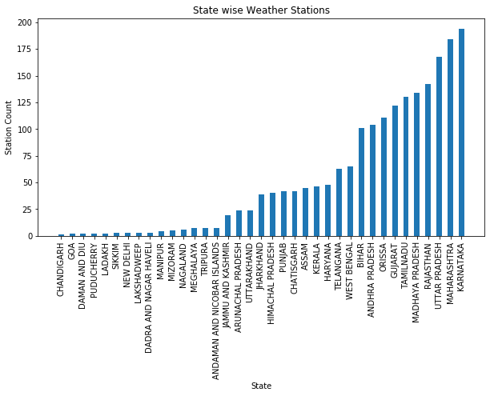

```python
fig = plt.figure(figsize=(10,5))
plt.xlabel("State")
plt.xticks(rotation=90)
plt.ylabel("Station Count",rotation=90)
plt.title("State wise Weather Stations")
plt.bar(stateWiseStationCount.State,stateWiseStationCount["count"],width=0.5)
#fig = plt.figure(figsize=(30,50))
fig.show()
```

```python
#write data to disk
weatherStationsWithId.write.option("header",True).csv("Datasets/Output/WeatherStationsId.csv")
```

```python
#Exporting to standard CSV file
weatherStationsWithId.toPandas().to_csv("Datasets/Output/WeatherStationsIdExport.csv")
```

```python
%%HTML
<style>div.input {display:none;}</style>
<div class='tableauPlaceholder' id='viz1601288506552' style='position: relative'><noscript><a href='#'><img alt=' ' src='https:&#47;&#47;public.tableau.com&#47;static&#47;images&#47;We&#47;WeatherStations_16012881337010&#47;DistrictMap&#47;1_rss.png' style='border: none' /></a></noscript><object class='tableauViz'  style='display:none;'><param name='host_url' value='https%3A%2F%2Fpublic.tableau.com%2F' /> <param name='embed_code_version' value='3' /> <param name='site_root' value='' /><param name='name' value='WeatherStations_16012881337010&#47;DistrictMap' /><param name='tabs' value='no' /><param name='toolbar' value='yes' /><param name='static_image' value='https:&#47;&#47;public.tableau.com&#47;static&#47;images&#47;We&#47;WeatherStations_16012881337010&#47;DistrictMap&#47;1.png' /> <param name='animate_transition' value='yes' /><param name='display_static_image' value='yes' /><param name='display_spinner' value='yes' /><param name='display_overlay' value='yes' /><param name='display_count' value='yes' /><param name='language' value='en' /><param name='filter' value='publish=yes' /></object></div>                <script type='text/javascript'>                    var divElement = document.getElementById('viz1601288506552');                    var vizElement = divElement.getElementsByTagName('object')[0];                    vizElement.style.width='100%';vizElement.style.height=(divElement.offsetWidth*0.75)+'px';                    var scriptElement = document.createElement('script');                    scriptElement.src = 'https://public.tableau.com/javascripts/api/viz_v1.js';                    vizElement.parentNode.insertBefore(scriptElement, vizElement);                </script>
```

[figure not shown]